# HW11: ML Fairness

```python
import pandas as pd
```

# Data Prep

```python
df = pd.read_csv('https://raw.githubusercontent.com/propublica/compas-analysis/master/compas-scores-two-years.csv')
df.head()
```

|  | id | name | first | last | compas_screening_date | sex | dob | age | age_cat | race | ... | v_decile_score | v_score_text | v_screening_date | in_custody | out_custody | priors_count.1 | start | end | event | two_year_recid |
| --- | --- | --- | --- | --- | --- | --- | --- | --- | --- | --- | --- | --- | --- | --- | --- | --- | --- | --- | --- | --- | --- |
| 0 | 1 | miguel hernandez | miguel | hernandez | 2013-08-14 | Male | 1947-04-18 | 69 | Greater than 45 | Other | ... | 1 | Low | 2013-08-14 | 2014-07-07 | 2014-07-14 | 0 | 0 | 327 | 0 | 0 |
| 1 | 3 | kevon dixon | kevon | dixon | 2013-01-27 | Male | 1982-01-22 | 34 | 25 - 45 | African-American | ... | 1 | Low | 2013-01-27 | 2013-01-26 | 2013-02-05 | 0 | 9 | 159 | 1 | 1 |
| 2 | 4 | ed philo | ed | philo | 2013-04-14 | Male | 1991-05-14 | 24 | Less than 25 | African-American | ... | 3 | Low | 2013-04-14 | 2013-06-16 | 2013-06-16 | 4 | 0 | 63 | 0 | 1 |
| 3 | 5 | marcu brown | marcu | brown | 2013-01-13 | Male | 1993-01-21 | 23 | Less than 25 | African-American | ... | 6 | Medium | 2013-01-13 | NaN | NaN | 1 | 0 | 1174 | 0 | 0 |
| 4 | 6 | bouthy pierrelouis | bouthy | pierrelouis | 2013-03-26 | Male | 1973-01-22 | 43 | 25 - 45 | Other | ... | 1 | Low | 2013-03-26 | NaN | NaN | 2 | 0 | 1102 | 0 | 0 |

5 rows × 53 columns

```python
df.columns
```

```
Index(['id', 'name', 'first', 'last', 'compas_screening_date', 'sex', 'dob',
       'age', 'age_cat', 'race', 'juv_fel_count', 'decile_score',
       'juv_misd_count', 'juv_other_count', 'priors_count',
       'days_b_screening_arrest', 'c_jail_in', 'c_jail_out', 'c_case_number',
       'c_offense_date', 'c_arrest_date', 'c_days_from_compas',
       'c_charge_degree', 'c_charge_desc', 'is_recid', 'r_case_number',
       'r_charge_degree', 'r_days_from_arrest', 'r_offense_date',
       'r_charge_desc', 'r_jail_in', 'r_jail_out', 'violent_recid',
       'is_violent_recid', 'vr_case_number', 'vr_charge_degree',
       'vr_offense_date', 'vr_charge_desc', 'type_of_assessment',
       'decile_score.1', 'score_text', 'screening_date',
       'v_type_of_assessment', 'v_decile_score', 'v_score_text',
       'v_screening_date', 'in_custody', 'out_custody', 'priors_count.1',
       'start', 'end', 'event', 'two_year_recid'],
      dtype='object')
```

```python
df['days_from_recid'] = pd.to_datetime(df['r_offense_date']) - pd.to_datetime(df['c_offense_date'])
df['days_from_recid'] = df['days_from_recid'].dt.days
df['two_year_recid2'] = df['days_from_recid']<=730
df['two_year_recid2'] = df['two_year_recid2'].astype(int)
```

```python
d = pd.get_dummies(df['c_charge_degree'])
df = pd.concat([df, d], axis=1)
df.head()
df = df.rename(columns={'F':'c_charge_degreeF'})
df = df.rename(columns={'M':'c_charge_degreeM'})
d = pd.get_dummies(df['age_cat'])
df = pd.concat([df, d], axis=1)
df = df.rename(columns={'25 - 45':'age_cat_25 - 45'})
df = df.rename(columns={'Greater than 45':'age_cat_Greater than 45'})
df = df.rename(columns={'Less than 25':'age_cat_Less than 25'})
d = pd.get_dummies(df['race'])
df = pd.concat([df, d], axis=1)
d = pd.get_dummies(df['sex'])
df = pd.concat([df, d], axis=1)
d = pd.get_dummies(df['score_text'])
df = pd.concat([df, d], axis=1)
df = df.rename(columns={'High':'score_text_high'})
df = df.rename(columns={'Medium':'score_text_medium'})
df = df.rename(columns={'Low':'score_text_low'})
```

```python
df['male'] = (df['sex'] == 'Male').astype(int)
df['felony'] = (df['c_charge_degree'] == 'F').astype(int)
```

```python
# judge decision: "jailed" = more than one day in jail.
df['jail_days'] = pd.to_datetime(df['c_jail_out']) - pd.to_datetime(df['c_jail_in'])
df['jailed'] = (df.jail_days.dt.days > 1).astype(int)
D = df['jailed']
D.value_counts()
```

```
0    4283
1    2931
Name: jailed, dtype: int64
```

```python
# ML outcome
Y = df['two_year_recid2']
Y.value_counts()
```

```
0    4557
1    2657
Name: two_year_recid2, dtype: int64
```

```python
# predictors
predictors = ['felony',
              'male', 'age',
              'juv_fel_count','juv_misd_count', 'juv_other_count', 'priors_count']
X = df[predictors]
X.describe()
```

|  | felony | male | age | juv_fel_count | juv_misd_count | juv_other_count | priors_count |
| --- | --- | --- | --- | --- | --- | --- | --- |
| count | 7214.000000 | 7214.000000 | 7214.000000 | 7214.000000 | 7214.000000 | 7214.000000 | 7214.000000 |
| mean | 0.646798 | 0.806626 | 34.817993 | 0.067230 | 0.090934 | 0.109371 | 3.472415 |
| std | 0.477998 | 0.394971 | 11.888922 | 0.473972 | 0.485239 | 0.501586 | 4.882538 |
| min | 0.000000 | 0.000000 | 18.000000 | 0.000000 | 0.000000 | 0.000000 | 0.000000 |
| 25% | 0.000000 | 1.000000 | 25.000000 | 0.000000 | 0.000000 | 0.000000 | 0.000000 |
| 50% | 1.000000 | 1.000000 | 31.000000 | 0.000000 | 0.000000 | 0.000000 | 2.000000 |
| 75% | 1.000000 | 1.000000 | 42.000000 | 0.000000 | 0.000000 | 0.000000 | 5.000000 |
| max | 1.000000 | 1.000000 | 96.000000 | 20.000000 | 13.000000 | 17.000000 | 38.000000 |

```python
df['race'].value_counts()
```

```
African-American    3696
Caucasian           2454
Hispanic             637
Other                377
Asian                 32
Native American       18
Name: race, dtype: int64
```

```python
# indicator variable for non-white
NW = (df['race'] != 'Caucasian').astype(int)
NW.describe()
```

```
count    7214.000000
mean        0.659828
std         0.473800
min         0.000000
25%         0.000000
50%         1.000000
75%         1.000000
max         1.000000
Name: race, dtype: float64
```

# Predict Recidivism from Features

Use logistic regression to predict recidivism from defendant features. Use nested training/test split so we can get clean test-set predictions for the whole dataset (see Lecture 6 Slide 9).

```python
# perform nested train/test split
from sklearn.model_selection import train_test_split
X_a, X_b, Y_a, Y_b, D_a, D_b,NW_a, NW_b = train_test_split(X, Y, D, NW, test_size = 0.5)

# train a logit model to predict recidism (Y) from predictors (X).
# form clean test-set predictions for recidivism in the full dataset
from sklearn.linear_model import LogisticRegression
logit = LogisticRegression()
# TODO
logit.fit(X_a, Y_a)
Yhat = logit.predict(X_b)
Ypred = logit.predict_proba(X_b)
print(Ypred)
print(Yhat)
```

```
[[0.81776692 0.18223308]
 [0.74576149 0.25423851]
 [0.65260771 0.34739229]
 ...
 [0.56872156 0.43127844]
 [0.53710979 0.46289021]
 [0.78013947 0.21986053]]
[0 0 0 ... 0 0 0]
```

Evaluate test set performance.

```
Accuracy:  0.6673135569725533
Balanced Accuracy: 0.568861798990116
Roc Auc:  0.568861798990116
              precision    recall  f1-score   support

           0       0.68      0.91      0.78      2327
           1       0.58      0.23      0.33      1280

    accuracy                           0.67      3607
   macro avg       0.63      0.57      0.55      3607
weighted avg       0.65      0.67      0.62      3607

0.21703853955375255
```

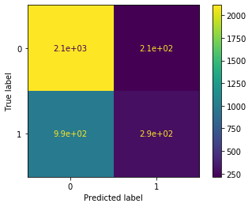

```python
# show a confusion matrix
from sklearn.metrics import (mean_squared_error, balanced_accuracy_score, roc_auc_score, f1_score, accuracy_score, confusion_matrix, plot_confusion_matrix)
from sklearn.metrics import classification_report

def gen_metrics(model, X, Y, Yhat):
    plot_confusion_matrix(model, X, Y)
    print('Accuracy: ', accuracy_score(Y, Yhat))
    print('Balanced Accuracy:', balanced_accuracy_score(Y, Yhat))
    print('Roc Auc: ', roc_auc_score(Y, Yhat))

    # show an sklearn classification report

    print(classification_report(Y, Yhat))

    # compute ratio of false positives to false negatives.
    conf_mat = confusion_matrix(Y, Yhat)
    ratio = conf_mat[0,1]/conf_mat[1,0]
    print(ratio)

gen_metrics(logit, X_b, Y_b, Yhat)
```

# Compare treatment of whites and non-whites for recidivism prediction

**Refore to Week 11 slides for these concepts.**

Compare base rates for recidivism outcomes of whites and non-whites

```python
NW_w = NW[NW == 0]
NW_o = NW[NW == 1]

Y_w = Y.drop(NW_o.index)
Y_o = Y.drop(NW_w.index)

recidivism_rate_w = Y_w.sum()/Y_w.shape[0]
recidivism_rate_o = Y_o.sum()/Y_o.shape[0]

print('recidivism rate for whites: ', recidivism_rate_w)
print('recidivism rate for non whites: ', recidivism_rate_o)
```

```
recidivism rate for whites:  0.3280358598207009
recidivism rate for non whites:  0.38907563025210085
```

Produce confusion matrices, classification reports, and ratio of false positives to false negatives, separately for whites and non-whites.

```
number of white samples:  1238
Accuracy:  0.7059773828756059
Balanced Accuracy: 0.5557802494101787
Roc Auc:  0.5557802494101787
              precision    recall  f1-score   support

           0       0.71      0.96      0.82       851
           1       0.62      0.16      0.25       387

    accuracy                           0.71      1238
   macro avg       0.67      0.56      0.53      1238
weighted avg       0.68      0.71      0.64      1238

0.11314984709480122
number of non white samples:  2369
Accuracy:  0.6471084845926551
Balanced Accuracy: 0.5710596873605914
Roc Auc:  0.5710596873605914
              precision    recall  f1-score   support

           0       0.66      0.88      0.76      1476
           1       0.57      0.26      0.36       893

    accuracy                           0.65      2369
   macro avg       0.62      0.57      0.56      2369
weighted avg       0.63      0.65      0.61      2369

0.26858877086494687
```

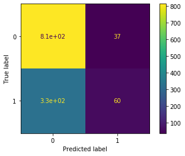

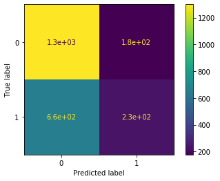

```python
# TODO
NW_b_w = NW_b[NW_b == 0]
NW_b_o = NW_b[NW_b == 1]

NW_b_flip = 1- NW_b

Y_b_w = Y_b.drop(NW_b_o.index)
X_b_w = X_b.drop(NW_b_o.index)
Yhat_w = Yhat[(NW_b_flip.to_numpy()).astype(bool)]
Y_b_o = Y_b.drop(NW_b_w.index)
X_b_o = X_b.drop(NW_b_w.index)
Yhat_o = Yhat[(NW_b.to_numpy()).astype(bool)]

#whites
print('number of white samples: ', NW_b_flip.sum())
gen_metrics(logit, X_b_w, Y_b_w, Yhat_w)
#non whites
print('number of non white samples: ', NW_b.sum())
gen_metrics(logit, X_b_o, Y_b_o, Yhat_o)
```

What concepts of "fairness" (from class) are (approximately) satisfied by this classifier? Explain.

[answer here]. The prescision and recall values seem to differ quite large between the white and noin white prisoners. When looking at those numbers and especially the ratio of false positives to false negatives one can see that whites are being treated less harsh by the robot judge which might be due to confounding variables in X.